# Kadaru Search System Analysis

Daniel M. Stelzer

2026-04-13

Comments from T and A: Error bars?

Import some libraries:

```r
library(tidyverse)
library(knitr)
library(kableExtra)
library(lme4)
library(lmerTest)
library(ggbeeswarm)
library(viridis)
```

Define some useful functions:

```r
show <- function(.data) {
  kable(.data, booktabs=TRUE, digits=4, escape=F, row.names=FALSE) %>% kable_styling()
}

`%notin%` <- negate(`%in%`)
```

## Import the data

The data is stored in `data_for_r.csv`, which was generated by `experiment_analyze.py` based on the various files in `tagged/`.

```r
raw <- read.csv("data_for_r.csv",
                header=TRUE,
                sep=",",
                stringsAsFactors=TRUE)
head(raw)
```

```
##   subject    time system         task accurate damage enrolled semesters list
## 1     AX1  33.862      H        1_gag        1      1        1         1   E1
## 2     AX1  24.725      H       0_ziz2        1      0        1         1   E1
## 3     AX1  89.501      H 0_sig2+munus        1      0        1         1   E1
## 4     AX1  84.936      H        3_sa5        1      3        1         1   E1
## 5     AX1 102.619      H       3_mac2        1      3        1         1   E1
## 6     AX1  43.063      H      2_dugud        1      2        1         1   E1
```

```r
str(raw)
```

```
## 'data.frame':    672 obs. of  9 variables:
##  $ subject  : Factor w/ 21 levels "AX1","AX2","AX3",..: 1 1 1 1 1 1 1 1 1 1 ...
##  $ time     : num  33.9 24.7 89.5 84.9 102.6 ...
##  $ system   : Factor w/ 3 levels "H","S","Z": 1 1 1 1 1 1 1 1 1 1 ...
##  $ task     : Factor w/ 48 levels "0_bal","0_ca3",..: 24 20 18 42 41 30 11 13 3 33 ...
##  $ accurate : int  1 1 1 1 1 1 0 1 1 0 ...
##  $ damage   : int  1 0 0 3 3 2 0 0 0 2 ...
##  $ enrolled : int  1 1 1 1 1 1 1 1 1 1 ...
##  $ semesters: num  1 1 1 1 1 1 1 1 1 1 ...
##  $ list     : Factor w/ 5 levels "E1","E2","E3",..: 1 1 1 1 1 1 1 1 1 1 ...
```

“Subject” is the three-character subject code: AX1 indicates that they used experimental lists 1 and 2 (“A”; “B” uses 2 and 3, “C” uses 3 and 1), used the Zeichenlexikon last (“X”; “Y” means the Zeichenlexikon came first), and were the first subject for this combination of factors (“1”).

Exceptions: PA1 indicates that they were part of the pilot experiment which always put the Zeichenlexikon last (“P”), used lists 1 and 2 (“A”; “B” uses 2 and 1), and were the first subject for this combination of factors (“1”). “E” indicates the first tests of the system; PBE is the experimenter themself.

“Accurate” is whether or not their identification was correct, and “time” is how many seconds it took them to make that identification.

“System” is “H” for Hantatallas (the code-based system), “S” for Sanhatallas (the drawing-based system), and “Z” for the Zeichenlexikon.

“Task” is the sign they were trying to identify, and “damage” is the first character of that field: 0 means no damage at all, 1 some strokes are obscured but all are present, 2 missing strokes, 3 missing components, and 4 mostly obliterated.

“Enrolled” is 1 if currently enrolled in a Hittite class and 0 if not; “semesters” is how many semesters of Hittite classes they’ve taken, including the current one.

“List” is which list was used (E1, E2, or E3: the practice lists S1 and S2 are filtered out in Python)

The order in which students tried the signs is documented, but not included here. Modify `experiment_analyze.py` if you need it.

## Factorize number of semesters

At first, the “semesters” value was always either 0 or 1. But later rounds have brought in subjects with much, *much* more experience, so keeping this as a numeric variable will skew the results.

```r
subject_sems <- raw %>% group_by(subject,semesters) %>% summarize()
subject_sems %>% show()
```

| subject | semesters |
| --- | --- |
| AX1 | 1.0 |
| AX2 | 0.0 |
| AX3 | 2.5 |
| AY1 | 1.0 |
| AY2 | 1.0 |
| BX1 | 0.0 |
| BX2 | 1.0 |
| BY1 | 1.0 |
| BY2 | 1.0 |
| BY3 | 8.0 |
| CX1 | 2.0 |
| CX2 | 1.0 |
| CX3 | 17.0 |
| CY1 | 1.0 |
| CY2 | 0.0 |
| PA1 | 1.0 |
| PA2 | 1.0 |
| PAE | 4.0 |
| PB1 | 1.0 |
| PB2 | 2.0 |
| PBE | 2.0 |

```r
subject_sems %>% group_by(semesters) %>% summarize(count=n()) %>% show()
```

| semesters | count |
| --- | --- |
| 0.0 | 3 |
| 1.0 | 11 |
| 2.0 | 3 |
| 2.5 | 1 |
| 4.0 | 1 |
| 8.0 | 1 |
| 17.0 | 1 |

It looks like the most useful categories will be “0”, “1”, and “2+”.

```r
cleaned_sems <- raw %>% mutate(experience = ifelse(semesters>=2.0, 2, round(semesters,0)))
cleaned_sems$experience = as.factor(cleaned_sems$experience)
levels(cleaned_sems$experience) = c("0", "1", "2+")
cleaned_sems$enrolled = as.factor(cleaned_sems$enrolled)
levels(cleaned_sems$enrolled) = c("no", "yes")
cleaned_sems %>% group_by(subject,experience) %>% summarize() %>% show()
```

| subject | experience |
| --- | --- |
| AX1 | 1 |
| AX2 | 0 |
| AX3 | 2+ |
| AY1 | 1 |
| AY2 | 1 |
| BX1 | 0 |
| BX2 | 1 |
| BY1 | 1 |
| BY2 | 1 |
| BY3 | 2+ |
| CX1 | 2+ |
| CX2 | 1 |
| CX3 | 2+ |
| CY1 | 1 |
| CY2 | 0 |
| PA1 | 1 |
| PA2 | 1 |
| PAE | 2+ |
| PB1 | 1 |
| PB2 | 2+ |
| PBE | 2+ |

## Remove outlier data points

If someone took 10 seconds or less on a task, they probably knew it from memory, which isn’t really testing their use of the system. Similarly, if they took 10 minutes or longer, they probably got distracted, which is similarly not testing their use of the system.

```r
sane <- cleaned_sems %>% filter(time > 10 & time < 600)
str(sane)
```

```
## 'data.frame':    645 obs. of  10 variables:
##  $ subject   : Factor w/ 21 levels "AX1","AX2","AX3",..: 1 1 1 1 1 1 1 1 1 1 ...
##  $ time      : num  33.9 24.7 89.5 84.9 102.6 ...
##  $ system    : Factor w/ 3 levels "H","S","Z": 1 1 1 1 1 1 1 1 1 1 ...
##  $ task      : Factor w/ 48 levels "0_bal","0_ca3",..: 24 20 18 42 41 30 11 13 3 33 ...
##  $ accurate  : int  1 1 1 1 1 1 0 1 1 0 ...
##  $ damage    : int  1 0 0 3 3 2 0 0 0 2 ...
##  $ enrolled  : Factor w/ 2 levels "no","yes": 2 2 2 2 2 2 2 2 2 2 ...
##  $ semesters : num  1 1 1 1 1 1 1 1 1 1 ...
##  $ list      : Factor w/ 5 levels "E1","E2","E3",..: 1 1 1 1 1 1 1 1 1 1 ...
##  $ experience: Factor w/ 3 levels "0","1","2+": 2 2 2 2 2 2 2 2 2 2 ...
```

What exactly did we remove?

```r
not_sane <- cleaned_sems %>% filter(time <= 10 | time >= 600)
str(not_sane)
```

```
## 'data.frame':    27 obs. of  10 variables:
##  $ subject   : Factor w/ 21 levels "AX1","AX2","AX3",..: 3 3 3 3 20 20 20 5 5 7 ...
##  $ time      : num  9.88 7.66 7.13 9.47 733.45 ...
##  $ system    : Factor w/ 3 levels "H","S","Z": 2 2 3 3 1 3 3 3 3 2 ...
##  $ task      : Factor w/ 48 levels "0_bal","0_ca3",..: 41 20 12 25 28 42 18 9 44 48 ...
##  $ accurate  : int  1 1 1 1 1 1 1 0 1 1 ...
##  $ damage    : int  3 0 0 1 2 3 0 0 3 4 ...
##  $ enrolled  : Factor w/ 2 levels "no","yes": 1 1 1 1 1 1 1 2 2 2 ...
##  $ semesters : num  2.5 2.5 2.5 2.5 2 2 2 1 1 1 ...
##  $ list      : Factor w/ 5 levels "E1","E2","E3",..: 1 1 2 2 5 4 4 2 2 2 ...
##  $ experience: Factor w/ 3 levels "0","1","2+": 3 3 3 3 3 3 3 2 2 2 ...
```

```r
not_sane %>% show()
```

| subject | time | system | task | accurate | damage | enrolled | semesters | list | experience |
| --- | --- | --- | --- | --- | --- | --- | --- | --- | --- |
| AX3 | 9.877 | S | 3_mac2 | 1 | 3 | no | 2.5 | E1 | 2+ |
| AX3 | 7.664 | S | 0_ziz2 | 1 | 0 | no | 2.5 | E1 | 2+ |
| AX3 | 7.134 | Z | 0_kid | 1 | 0 | no | 2.5 | E2 | 2+ |
| AX3 | 9.470 | Z | 1_gal | 1 | 1 | no | 2.5 | E2 | 2+ |
| PB2 | 733.451 | H | 2_alam | 1 | 2 | no | 2.0 | P2 | 2+ |
| PB2 | 934.277 | Z | 3_sa5 | 1 | 3 | no | 2.0 | P1 | 2+ |
| PB2 | 633.422 | Z | 0_sig2+munus | 1 | 0 | no | 2.0 | P1 | 2+ |
| AY2 | 718.749 | Z | 0_hub | 0 | 0 | yes | 1.0 | E2 | 1 |
| AY2 | 899.697 | Z | 3_sir3 | 1 | 3 | yes | 1.0 | E2 | 1 |
| BX2 | 683.325 | S | 4_tu7 | 1 | 4 | yes | 1.0 | E2 | 1 |
| BY2 | 6.201 | S | 0_hub | 1 | 0 | yes | 1.0 | E2 | 1 |
| CX3 | 6.967 | S | 2_e2 | 1 | 2 | yes | 17.0 | E3 | 2+ |
| CX3 | 9.537 | S | 1_2 | 1 | 1 | yes | 17.0 | E3 | 2+ |
| CX3 | 5.266 | S | 2_lal3 | 1 | 2 | yes | 17.0 | E3 | 2+ |
| CX3 | 7.125 | S | 0_gu4 | 1 | 0 | yes | 17.0 | E3 | 2+ |
| CX3 | 6.519 | S | 0_hur | 1 | 0 | yes | 17.0 | E3 | 2+ |
| CX3 | 4.941 | S | 0_bal | 1 | 0 | yes | 17.0 | E3 | 2+ |
| CX3 | 6.897 | S | 0_ezen4 | 1 | 0 | yes | 17.0 | E3 | 2+ |
| CX3 | 7.230 | S | 2_mec | 1 | 2 | yes | 17.0 | E3 | 2+ |
| CX3 | 7.880 | Z | 2_dugud | 1 | 2 | yes | 17.0 | E1 | 2+ |
| CX3 | 6.095 | Z | 0_kiri6 | 1 | 0 | yes | 17.0 | E1 | 2+ |
| CX3 | 6.215 | Z | 4_6 | 0 | 4 | yes | 17.0 | E1 | 2+ |
| CX3 | 7.707 | Z | 1_gag | 1 | 1 | yes | 17.0 | E1 | 2+ |
| AX2 | 634.684 | Z | 0_hub | 1 | 0 | no | 0.0 | E2 | 0 |
| AY1 | 718.318 | Z | 0_sanga | 0 | 0 | yes | 1.0 | E2 | 1 |
| PAE | 828.416 | Z | 3_sir3 | 1 | 3 | no | 4.0 | P2 | 2+ |
| BX1 | 607.549 | H | 4_tu7 | 0 | 4 | no | 0.0 | E2 | 0 |

```r
not_sane %>% mutate(whichway=ifelse(time<=10,"fast","slow")) %>% group_by(subject, system, whichway) %>% summarize(count=n()) %>% show()
```

| subject | system | whichway | count |
| --- | --- | --- | --- |
| AX2 | Z | slow | 1 |
| AX3 | S | fast | 2 |
| AX3 | Z | fast | 2 |
| AY1 | Z | slow | 1 |
| AY2 | Z | slow | 2 |
| BX1 | H | slow | 1 |
| BX2 | S | slow | 1 |
| BY2 | S | fast | 1 |
| CX3 | S | fast | 8 |
| CX3 | Z | fast | 4 |
| PAE | Z | slow | 1 |
| PB2 | H | slow | 1 |
| PB2 | Z | slow | 2 |

## Remove outlier subjects

The original plan was to remove all subjects with an overall accuracy of 50% or less on any system, on the assumption they weren’t paying attention. But running the analysis both ways, including them helps the standard error (more data is good!) and doesn’t meaningfully change the results. So for now, we include them.

We *do* need to remove subject PBE, who is the creator of Hantatallas and thus ended up with an accuracy of 100% on that system. We’re interested in how *other* people use the system, not its creator who designed the experiment. For symmetry, we could also remove PAE (the other initial test of the apparatus), once we have enough other data; however, this person was not involved in the development of Hantatallas or the selection of tasks, so for now we leave them in.

```r
raw_accs <- sane %>% group_by(subject, system) %>% summarize(accuracy=mean(accurate))
raw_accs %>% show()
```

| subject | system | accuracy |
| --- | --- | --- |
| AX1 | H | 0.8750 |
| AX1 | Z | 0.8125 |
| AX2 | S | 0.8125 |
| AX2 | Z | 0.7333 |
| AX3 | S | 0.4286 |
| AX3 | Z | 0.4286 |
| AY1 | H | 0.4375 |
| AY1 | Z | 0.3333 |
| AY2 | S | 0.6875 |
| AY2 | Z | 0.8571 |
| BX1 | H | 0.5333 |
| BX1 | Z | 0.4375 |
| BX2 | S | 0.9333 |
| BX2 | Z | 0.8125 |
| BY1 | H | 0.8750 |
| BY1 | Z | 0.6875 |
| BY2 | S | 0.8667 |
| BY2 | Z | 0.7500 |
| BY3 | S | 0.9375 |
| BY3 | Z | 0.9375 |
| CX1 | H | 0.8750 |
| CX1 | Z | 0.6250 |
| CX2 | S | 0.7500 |
| CX2 | Z | 0.8125 |
| CX3 | S | 1.0000 |
| CX3 | Z | 0.7500 |
| CY1 | H | 0.9375 |
| CY1 | Z | 0.6875 |
| CY2 | S | 0.8125 |
| CY2 | Z | 0.6875 |
| PA1 | H | 0.8750 |
| PA1 | Z | 0.7500 |
| PA2 | H | 0.5000 |
| PA2 | Z | 0.5625 |
| PAE | H | 0.6875 |
| PAE | Z | 0.6000 |
| PB1 | H | 0.7500 |
| PB1 | Z | 0.6875 |
| PB2 | H | 0.8000 |
| PB2 | Z | 0.7857 |
| PBE | H | 1.0000 |
| PBE | Z | 0.9375 |

Which of these is not greater than 50%? (Or PBE.) Previously we used “accuracy >= 100.0” to exclude subject PBE here, but subject CX3 later achieved an accuracy of 100% with system S, so now we test for PBE explicitly.

```r
accs_to_remove <- raw_accs %>% filter(accuracy <= 0.5 | subject == 'PBE')
show(accs_to_remove)
```

| subject | system | accuracy |
| --- | --- | --- |
| AX3 | S | 0.4286 |
| AX3 | Z | 0.4286 |
| AY1 | H | 0.4375 |
| AY1 | Z | 0.3333 |
| BX1 | Z | 0.4375 |
| PA2 | H | 0.5000 |
| PBE | H | 1.0000 |
| PBE | Z | 0.9375 |

So previously, we would exclude AX3, AY1, BX1, PA2, and PBE.

```r
removed_subjects <- unique(accs_to_remove$subject)
removed_subjects
```

```
## [1] AX3 AY1 BX1 PA2 PBE
## 21 Levels: AX1 AX2 AX3 AY1 AY2 BX1 BX2 BY1 BY2 BY3 CX1 CX2 CX3 CY1 CY2 ... PBE
```

Now, though, we don’t remove them. Instead, we include all subjects except PBE.

(Three subjects’ data had to be removed for IRB reasons. Those are filtered out in the Python code and never make it into R in the first place, just to be safe.)

```r
#filtered <- sane %>% filter(subject %notin% removed_subjects)
filtered <- sane %>% filter(subject != "PBE")
tmp_accs <- raw_accs %>% filter(subject != "PBE")
str(filtered)
```

```
## 'data.frame':    613 obs. of  10 variables:
##  $ subject   : Factor w/ 21 levels "AX1","AX2","AX3",..: 1 1 1 1 1 1 1 1 1 1 ...
##  $ time      : num  33.9 24.7 89.5 84.9 102.6 ...
##  $ system    : Factor w/ 3 levels "H","S","Z": 1 1 1 1 1 1 1 1 1 1 ...
##  $ task      : Factor w/ 48 levels "0_bal","0_ca3",..: 24 20 18 42 41 30 11 13 3 33 ...
##  $ accurate  : int  1 1 1 1 1 1 0 1 1 0 ...
##  $ damage    : int  1 0 0 3 3 2 0 0 0 2 ...
##  $ enrolled  : Factor w/ 2 levels "no","yes": 2 2 2 2 2 2 2 2 2 2 ...
##  $ semesters : num  1 1 1 1 1 1 1 1 1 1 ...
##  $ list      : Factor w/ 5 levels "E1","E2","E3",..: 1 1 1 1 1 1 1 1 1 1 ...
##  $ experience: Factor w/ 3 levels "0","1","2+": 2 2 2 2 2 2 2 2 2 2 ...
```

## Divide subjects into Z-H and Z-S categories

All subjects used the Zeichenlexikon (Z) and either Hantatallas (H) or Sanhatallas (S). For various parts of the upcoming analysis, we want to handle the Z-H subjects separately from the Z-S subjects, so that we can investigate each system individually.

```r
tmp_used_h <- filtered %>% filter(system=="H")
subjs_used_h <- unique(tmp_used_h$subject)
subjs_used_h
```

```
##  [1] AX1 PB2 BY1 PB1 PA2 AY1 PAE CX1 CY1 PA1 BX1
## 21 Levels: AX1 AX2 AX3 AY1 AY2 BX1 BX2 BY1 BY2 BY3 CX1 CX2 CX3 CY1 CY2 ... PBE
```

```r
tmp_used_s <- filtered %>% filter(system=="S")
subjs_used_s <- unique(tmp_used_s$subject)
subjs_used_s
```

```
## [1] BY3 CY2 AX3 AY2 BX2 BY2 CX3 AX2 CX2
## 21 Levels: AX1 AX2 AX3 AY1 AY2 BX1 BX2 BY1 BY2 BY3 CX1 CX2 CX3 CY1 CY2 ... PBE
```

## Analyze accuracy

Let’s get an overview of the overall accuracy.

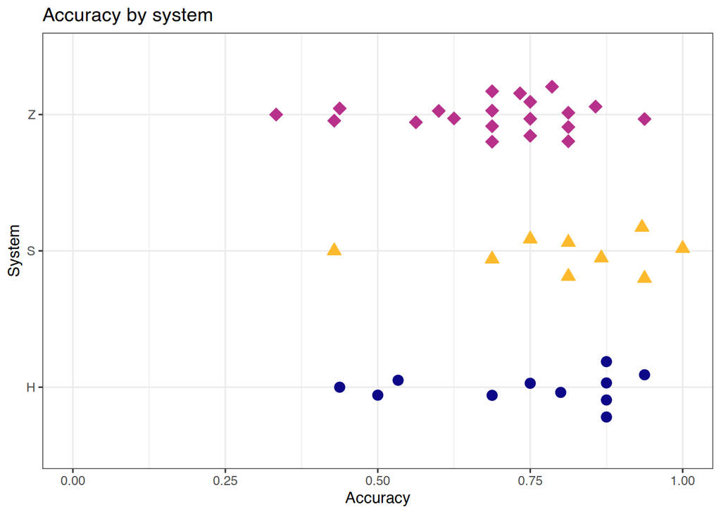

```r
#set.seed(1)

tmp_accs_2 <- tmp_accs %>% mutate(sysadjust=ifelse(system=='H',0,ifelse(system=='S',1,0.5)))

ggplot(data=tmp_accs_2) +
    aes(x=accuracy, y=system, color=as.factor(sysadjust), shape=system, fill=as.factor(sysadjust)) +
#    geom_jitter(width=0.01, height=0.25) +
    geom_quasirandom(orientation='y', groupOnX=FALSE, width=0.25, size=3) +
    scale_shape_manual(values=c(21,24,23)) +
    scale_color_viridis(discrete=TRUE, option="plasma", begin=0, end=0.85) +
    scale_fill_viridis(discrete=TRUE, option="plasma", begin=0, end=0.85) +
    theme_bw() +
    labs(title='Accuracy by system', x='Accuracy', y='System', shape=NULL, color=NULL, fill=NULL) +
    guides(color="none", shape="none", fill="none") +
    xlim(0,1)
```

```r
ggsave('r_overall_accuracy.pdf', width=6, height=4, units="in")
```

Including “enrolled” and “experience” in the grouping, since they don’t vary by subject or system, ensures that they end up in the summary afterward.

```r
accuracy <- filtered %>% group_by(subject, system, enrolled, experience) %>% summarize(accuracy = mean(accurate))
show(accuracy)
```

| subject | system | enrolled | experience | accuracy |
| --- | --- | --- | --- | --- |
| AX1 | H | yes | 1 | 0.8750 |
| AX1 | Z | yes | 1 | 0.8125 |
| AX2 | S | no | 0 | 0.8125 |
| AX2 | Z | no | 0 | 0.7333 |
| AX3 | S | no | 2+ | 0.4286 |
| AX3 | Z | no | 2+ | 0.4286 |
| AY1 | H | yes | 1 | 0.4375 |
| AY1 | Z | yes | 1 | 0.3333 |
| AY2 | S | yes | 1 | 0.6875 |
| AY2 | Z | yes | 1 | 0.8571 |
| BX1 | H | no | 0 | 0.5333 |
| BX1 | Z | no | 0 | 0.4375 |
| BX2 | S | yes | 1 | 0.9333 |
| BX2 | Z | yes | 1 | 0.8125 |
| BY1 | H | yes | 1 | 0.8750 |
| BY1 | Z | yes | 1 | 0.6875 |
| BY2 | S | yes | 1 | 0.8667 |
| BY2 | Z | yes | 1 | 0.7500 |
| BY3 | S | yes | 2+ | 0.9375 |
| BY3 | Z | yes | 2+ | 0.9375 |
| CX1 | H | no | 2+ | 0.8750 |
| CX1 | Z | no | 2+ | 0.6250 |
| CX2 | S | yes | 1 | 0.7500 |
| CX2 | Z | yes | 1 | 0.8125 |
| CX3 | S | yes | 2+ | 1.0000 |
| CX3 | Z | yes | 2+ | 0.7500 |
| CY1 | H | yes | 1 | 0.9375 |
| CY1 | Z | yes | 1 | 0.6875 |
| CY2 | S | no | 0 | 0.8125 |
| CY2 | Z | no | 0 | 0.6875 |
| PA1 | H | no | 1 | 0.8750 |
| PA1 | Z | no | 1 | 0.7500 |
| PA2 | H | no | 1 | 0.5000 |
| PA2 | Z | no | 1 | 0.5625 |
| PAE | H | no | 2+ | 0.6875 |
| PAE | Z | no | 2+ | 0.6000 |
| PB1 | H | no | 1 | 0.7500 |
| PB1 | Z | no | 1 | 0.6875 |
| PB2 | H | no | 2+ | 0.8000 |
| PB2 | Z | no | 2+ | 0.7857 |

Now we have our subject variable, one within-subjects variable (system), two between-subjects variables (enrolled and experience), and our output variable (accuracy). But is an ANOVA really the right thing to use here?

```r
accs_h <- accuracy %>% filter(subject %in% subjs_used_h)
accs_s <- accuracy %>% filter(subject %in% subjs_used_s)
```

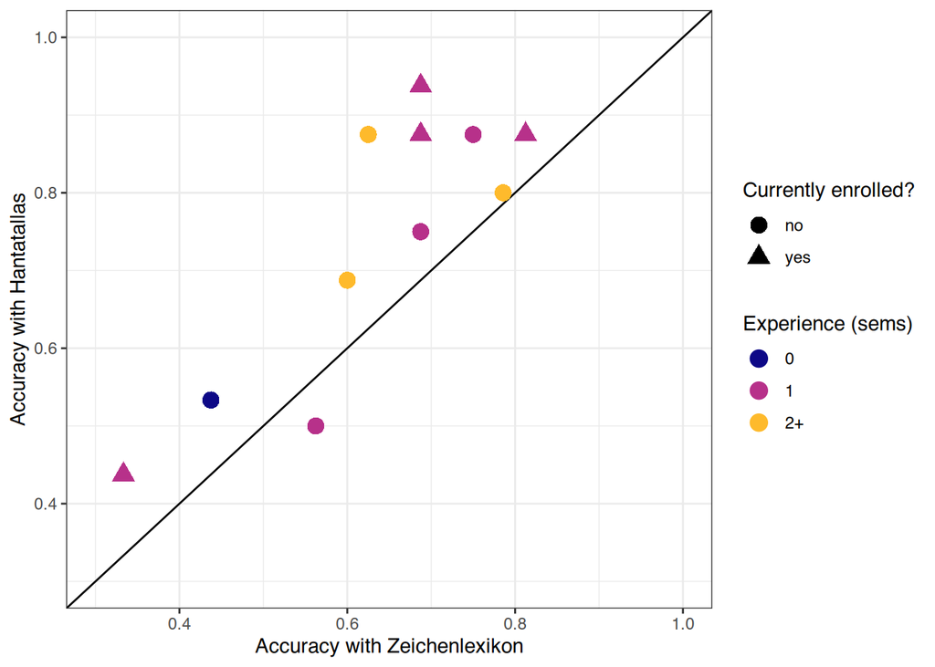

```r
ggplot(data=pivot_wider(accs_h, names_from=system, values_from=accuracy)) +
    geom_abline(slope=1, intercept=0) +
    geom_point(mapping=aes(x=Z, y=H, colour=experience, shape=enrolled), size=4) +
    xlim(0.3, 1.0) + ylim(0.3, 1.0) + theme_bw() +
    scale_color_viridis(discrete=TRUE, option="plasma", begin=0, end=0.85) +
    labs(x="Accuracy with Zeichenlexikon", y="Accuracy with Hantatallas", shape="Currently enrolled?", colour="Experience (sems)")
```

```r
ggsave('r_acc_h.pdf', width=6, height=4, units="in")
```

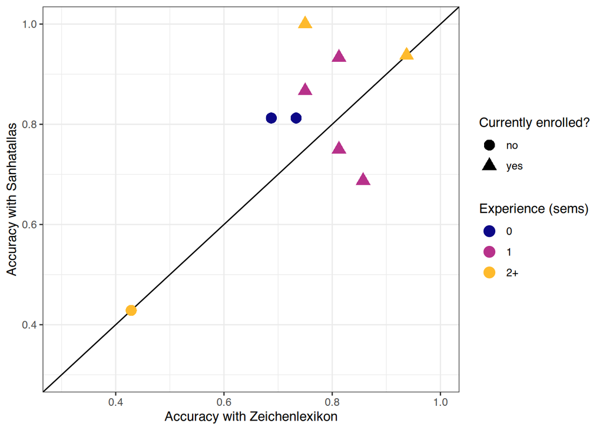

```r
ggplot(data=pivot_wider(accs_s, names_from=system, values_from=accuracy)) +
    geom_abline(slope=1, intercept=0) +
    geom_point(mapping=aes(x=Z, y=S, colour=experience, shape=enrolled), size=4) +
    xlim(0.3, 1.0) + ylim(0.3, 1.0) + theme_bw() +
    scale_color_viridis(discrete=TRUE, option="plasma", begin=0, end=0.85) +
    labs(x="Accuracy with Zeichenlexikon", y="Accuracy with Sanhatallas", shape="Currently enrolled?", colour="Experience (sems)")
```

```r
ggsave('r_acc_s.pdf', width=6, height=4, units="in")
```

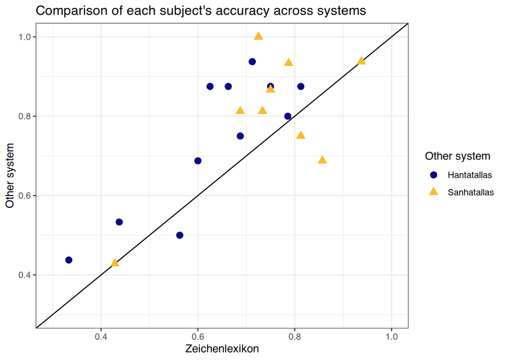

```r
set.seed(2)

ggplot() +
    geom_abline(slope=1, intercept=0) +
    geom_quasirandom(groupOnX=TRUE, data=pivot_wider(accs_h, names_from=system, values_from=accuracy),
               mapping=aes(x=Z, y=H, shape='Hantatallas', color='Hantatallas'),
               width=0.05, size=3) +
    geom_quasirandom(groupOnX=TRUE, data=pivot_wider(accs_s, names_from=system, values_from=accuracy),
               mapping=aes(x=Z, y=S, shape='Sanhatallas', color='Sanhatallas'),
               width=0.05, size=3) +
    xlim(0.3, 1.0) + ylim(0.3, 1.0) + theme_bw() +
    scale_color_viridis(discrete=TRUE, option="plasma", begin=0, end=0.85) +
    labs(shape='Other system', color='Other system', x='Zeichenlexikon', y='Other system', title="Comparison of each subject's accuracy across systems")
```

```r
ggsave('r_accuracy_compare.pdf', width=6, height=4, units="in")
```

Since we only have one accuracy measure per treatment per student, we can use a repeated-measures t-test. We should probably check the assumptions first, though:

```r
accs_h_wide = pivot_wider(accs_h, names_from=system, values_from=accuracy) %>% mutate(diff=H-Z)
accs_s_wide = pivot_wider(accs_s, names_from=system, values_from=accuracy) %>% mutate(diff=S-Z)
head(accs_h_wide)
```

```
## # A tibble: 6 × 6
## # Groups:   subject, enrolled [6]
##   subject enrolled experience     H     Z   diff
##   <fct>   <fct>    <fct>      <dbl> <dbl>  <dbl>
## 1 AX1     yes      1          0.875 0.812 0.0625
## 2 AY1     yes      1          0.438 0.333 0.104
## 3 BX1     no       0          0.533 0.438 0.0958
## 4 BY1     yes      1          0.875 0.688 0.188
## 5 CX1     no       2+         0.875 0.625 0.25
## 6 CY1     yes      1          0.938 0.688 0.25
```

My favorite way to do this is with a Q-Q plot, because it means we can look at nice plots and eyeball it instead of just staring at a column of numbers.

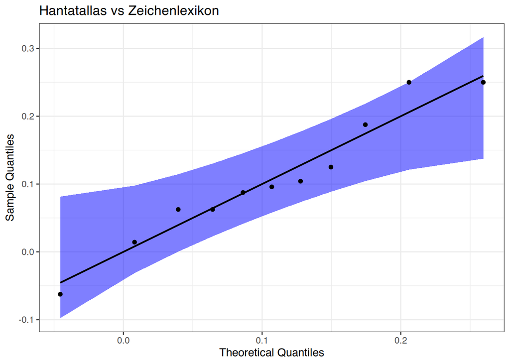

```r
is_qqplotr_available <- require(qqplotr)
if(is_qqplotr_available) {
ggplot(data=accs_h_wide, mapping=aes(sample=diff)) +
  stat_qq_band(alpha = 0.5, conf = 0.95, bandType = "pointwise", fill = "blue") +
  stat_qq_line(identity = TRUE) +
  stat_qq_point(col = "black") +
  labs(x = "Theoretical Quantiles", y = "Sample Quantiles", title="Hantatallas vs Zeichenlexikon") +
  theme_bw()
} else {
  print("QQPlotR not available :( install it for pretty pictures!")
}
```

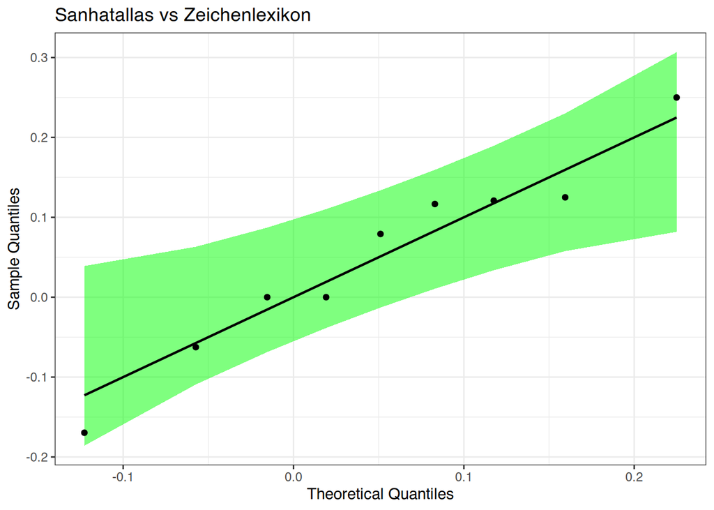

```r
if(is_qqplotr_available) {
ggplot(data=accs_s_wide, mapping=aes(sample=diff)) +
  stat_qq_band(alpha = 0.5, conf = 0.95, bandType = "pointwise", fill = "green") +
  stat_qq_line(identity = TRUE) +
  stat_qq_point(col = "black") +
  labs(x = "Theoretical Quantiles", y = "Sample Quantiles", title="Sanhatallas vs Zeichenlexikon") +
  theme_bw()
} else {
  print("QQPlotR not available :( install it for pretty pictures!")
}
```

But we can also do a Shapiro-Wilk test for numerical confidence.

```r
shapiro.test(accs_h_wide$diff)
```

```
##
##  Shapiro-Wilk normality test
##
## data:  accs_h_wide$diff
## W = 0.9495, p-value = 0.6376
```

```r
shapiro.test(accs_s_wide$diff)
```

```
##
##  Shapiro-Wilk normality test
##
## data:  accs_s_wide$diff
## W = 0.96499, p-value = 0.8489
```

Now, do the test!

```r
t.test(x=accs_h_wide$H, y=accs_h_wide$Z, paired=TRUE)
```

```
##
##  Paired t-test
##
## data:  accs_h_wide$H and accs_h_wide$Z
## t = 3.7505, df = 10, p-value = 0.003781
## alternative hypothesis: true mean difference is not equal to 0
## 95 percent confidence interval:
##  0.04342372 0.17053732
## sample estimates:
## mean difference
##       0.1069805
```

```r
t.test(x=accs_s_wide$S, y=accs_s_wide$Z, paired=TRUE)
```

```
##
##  Paired t-test
##
## data:  accs_s_wide$S and accs_s_wide$Z
## t = 1.2413, df = 8, p-value = 0.2497
## alternative hypothesis: true mean difference is not equal to 0
## 95 percent confidence interval:
##  -0.04379784  0.14591424
## sample estimates:
## mean difference
##       0.0510582
```

We could also try a Wilcox test here (replace t.test with wilcox.test), which doesn’t require the assumption of normality.

```r
wilcox.test(x=accs_h_wide$H, y=accs_h_wide$Z, paired=TRUE)
```

```
##
##  Wilcoxon signed rank test with continuity correction
##
## data:  accs_h_wide$H and accs_h_wide$Z
## V = 63, p-value = 0.008554
## alternative hypothesis: true location shift is not equal to 0
```

```r
wilcox.test(x=accs_s_wide$S, y=accs_s_wide$Z, paired=TRUE)
```

```
##
##  Wilcoxon signed rank test with continuity correction
##
## data:  accs_s_wide$S and accs_s_wide$Z
## V = 21, p-value = 0.2719
## alternative hypothesis: true location shift is not equal to 0
```

To get more details, we can use a generalized linear mixed model (GLMM). This basically does the same thing as the above, but uses *all* the data points instead of just the average of them.

```r
glmm <- glmer(accurate ~ relevel(system, ref="Z") + (1|task) + (1|experience) + (1|subject), data=filtered, family=binomial(link="logit"))
```

```
## boundary (singular) fit: see help('isSingular')
```

```r
summary(glmm)
```

```
## Generalized linear mixed model fit by maximum likelihood (Laplace
##   Approximation) [glmerMod]
##  Family: binomial  ( logit )
## Formula:
## accurate ~ relevel(system, ref = "Z") + (1 | task) + (1 | experience) +
##     (1 | subject)
##    Data: filtered
##
##       AIC       BIC    logLik -2*log(L)  df.resid
##     635.7     662.2    -311.9     623.7       607
##
## Scaled residuals:
##     Min      1Q  Median      3Q     Max
## -4.2064 -0.5015  0.3172  0.4940  1.8679
##
## Random effects:
##  Groups     Name        Variance Std.Dev.
##  task       (Intercept) 1.625    1.2746
##  subject    (Intercept) 0.697    0.8349
##  experience (Intercept) 0.000    0.0000
## Number of obs: 613, groups:  task, 48; subject, 20; experience, 3
##
## Fixed effects:
##                             Estimate Std. Error z value Pr(>|z|)
## (Intercept)                   1.1231     0.3047   3.686 0.000228 ***
## relevel(system, ref = "Z")H   0.6130     0.2702   2.268 0.023305 *
## relevel(system, ref = "Z")S   0.5254     0.3178   1.653 0.098263 .
## ---
## Signif. codes:  0 '***' 0.001 '**' 0.01 '*' 0.05 '.' 0.1 ' ' 1
##
## Correlation of Fixed Effects:
##             (Intr) r(,r="Z")H
## rl(,r="Z")H -0.217
## rl(,r="Z")S -0.220  0.086
## optimizer (Nelder_Mead) convergence code: 0 (OK)
## boundary (singular) fit: see help('isSingular')
```

It looks like `experience` is not useful in this model. Let’s re-run it, removing that.

```r
glmm <- glmer(accurate ~ relevel(system, ref="Z") + (1|task) + (1|subject), data=filtered, family=binomial(link="logit"))
summary(glmm)
```

```
## Generalized linear mixed model fit by maximum likelihood (Laplace
##   Approximation) [glmerMod]
##  Family: binomial  ( logit )
## Formula: accurate ~ relevel(system, ref = "Z") + (1 | task) + (1 | subject)
##    Data: filtered
##
##       AIC       BIC    logLik -2*log(L)  df.resid
##     633.7     655.8    -311.9     623.7       608
##
## Scaled residuals:
##     Min      1Q  Median      3Q     Max
## -4.2064 -0.5015  0.3172  0.4940  1.8679
##
## Random effects:
##  Groups  Name        Variance Std.Dev.
##  task    (Intercept) 1.625    1.2746
##  subject (Intercept) 0.697    0.8349
## Number of obs: 613, groups:  task, 48; subject, 20
##
## Fixed effects:
##                             Estimate Std. Error z value Pr(>|z|)
## (Intercept)                   1.1231     0.3047   3.686 0.000228 ***
## relevel(system, ref = "Z")H   0.6130     0.2702   2.268 0.023304 *
## relevel(system, ref = "Z")S   0.5254     0.3178   1.653 0.098265 .
## ---
## Signif. codes:  0 '***' 0.001 '**' 0.01 '*' 0.05 '.' 0.1 ' ' 1
##
## Correlation of Fixed Effects:
##             (Intr) r(,r="Z")H
## rl(,r="Z")H -0.217
## rl(,r="Z")S -0.220  0.086
```

## Analyze time

For time, we have several different data points per system per subject, and we don’t want to entirely collapse those down into a single mean. So instead of a simple t-test (or ANOVA), we do a mixed-effects linear model. (And we use lmerTest to get a p-value, even though the author of lme4 dislikes that, just because publishers are going to want one. Alas.)

The dataset we’re using here is the `filtered` one, with outlier data points removed.

```r
str(filtered)
```

```
## 'data.frame':    613 obs. of  10 variables:
##  $ subject   : Factor w/ 21 levels "AX1","AX2","AX3",..: 1 1 1 1 1 1 1 1 1 1 ...
##  $ time      : num  33.9 24.7 89.5 84.9 102.6 ...
##  $ system    : Factor w/ 3 levels "H","S","Z": 1 1 1 1 1 1 1 1 1 1 ...
##  $ task      : Factor w/ 48 levels "0_bal","0_ca3",..: 24 20 18 42 41 30 11 13 3 33 ...
##  $ accurate  : int  1 1 1 1 1 1 0 1 1 0 ...
##  $ damage    : int  1 0 0 3 3 2 0 0 0 2 ...
##  $ enrolled  : Factor w/ 2 levels "no","yes": 2 2 2 2 2 2 2 2 2 2 ...
##  $ semesters : num  1 1 1 1 1 1 1 1 1 1 ...
##  $ list      : Factor w/ 5 levels "E1","E2","E3",..: 1 1 1 1 1 1 1 1 1 1 ...
##  $ experience: Factor w/ 3 levels "0","1","2+": 2 2 2 2 2 2 2 2 2 2 ...
```

But it still includes inaccurate answers. We’d like to run our mixed-effects model both with inaccurate answers included, and with them excluded.

```r
only_accurate <- filtered %>% filter(accurate==1)
str(only_accurate)
```

```
## 'data.frame':    445 obs. of  10 variables:
##  $ subject   : Factor w/ 21 levels "AX1","AX2","AX3",..: 1 1 1 1 1 1 1 1 1 1 ...
##  $ time      : num  33.9 24.7 89.5 84.9 102.6 ...
##  $ system    : Factor w/ 3 levels "H","S","Z": 1 1 1 1 1 1 1 1 1 1 ...
##  $ task      : Factor w/ 48 levels "0_bal","0_ca3",..: 24 20 18 42 41 30 13 3 27 8 ...
##  $ accurate  : int  1 1 1 1 1 1 1 1 1 1 ...
##  $ damage    : int  1 0 0 3 3 2 0 0 1 0 ...
##  $ enrolled  : Factor w/ 2 levels "no","yes": 2 2 2 2 2 2 2 2 2 2 ...
##  $ semesters : num  1 1 1 1 1 1 1 1 1 1 ...
##  $ list      : Factor w/ 5 levels "E1","E2","E3",..: 1 1 1 1 1 1 1 1 1 1 ...
##  $ experience: Factor w/ 3 levels "0","1","2+": 2 2 2 2 2 2 2 2 2 2 ...
```

First, run with inaccurate ones included…

```r
mixed <- lmer(time ~ relevel(system, ref="Z") + (1|subject) + (1|task), data=filtered)
summary(mixed)
```

```
## Linear mixed model fit by REML. t-tests use Satterthwaite's method [
## lmerModLmerTest]
## Formula: time ~ relevel(system, ref = "Z") + (1 | subject) + (1 | task)
##    Data: filtered
##
## REML criterion at convergence: 7270.3
##
## Scaled residuals:
##     Min      1Q  Median      3Q     Max
## -2.2351 -0.6165 -0.2075  0.3346  4.2069
##
## Random effects:
##  Groups   Name        Variance Std.Dev.
##  task     (Intercept) 2122.0   46.07
##  subject  (Intercept)  751.7   27.42
##  Residual             7282.1   85.34
## Number of obs: 613, groups:  task, 48; subject, 20
##
## Fixed effects:
##                             Estimate Std. Error      df t value Pr(>|t|)
## (Intercept)                  155.732     10.296  52.607  15.126  < 2e-16 ***
## relevel(system, ref = "Z")H  -30.588      8.806 534.843  -3.473 0.000555 ***
## relevel(system, ref = "Z")S  -35.206      9.915 496.627  -3.551 0.000421 ***
## ---
## Signif. codes:  0 '***' 0.001 '**' 0.01 '*' 0.05 '.' 0.1 ' ' 1
##
## Correlation of Fixed Effects:
##             (Intr) r(,r="Z")H
## rl(,r="Z")H -0.259
## rl(,r="Z")S -0.236  0.107
```

…then excluded.

```r
mixed <- lmer(time ~ relevel(system, ref="Z") + (1|subject) + (1|task), data=only_accurate)
summary(mixed)
```

```
## Linear mixed model fit by REML. t-tests use Satterthwaite's method [
## lmerModLmerTest]
## Formula: time ~ relevel(system, ref = "Z") + (1 | subject) + (1 | task)
##    Data: only_accurate
##
## REML criterion at convergence: 5174.6
##
## Scaled residuals:
##     Min      1Q  Median      3Q     Max
## -1.8089 -0.5893 -0.2352  0.3219  4.0883
##
## Random effects:
##  Groups   Name        Variance Std.Dev.
##  task     (Intercept) 1847.3   42.98
##  subject  (Intercept)  635.1   25.20
##  Residual             5661.4   75.24
## Number of obs: 445, groups:  task, 48; subject, 20
##
## Fixed effects:
##                             Estimate Std. Error     df t value Pr(>|t|)
## (Intercept)                   144.33      10.03  50.69  14.386  < 2e-16 ***
## relevel(system, ref = "Z")H   -29.26       9.36 372.46  -3.126  0.00191 **
## relevel(system, ref = "Z")S   -35.46      10.02 376.60  -3.540  0.00045 ***
## ---
## Signif. codes:  0 '***' 0.001 '**' 0.01 '*' 0.05 '.' 0.1 ' ' 1
##
## Correlation of Fixed Effects:
##             (Intr) r(,r="Z")H
## rl(,r="Z")H -0.316
## rl(,r="Z")S -0.272  0.147
```

We see less significance here because we threw out a bunch of data, so the standard error increased. But the overall results are not substantially different. Let’s keep the inaccurate times in going forward.

Let’s make a visualization to sanity-check these results, showing the difference in mean time by system by subject.

```r
mean_times <- filtered %>% group_by(subject, system, experience) %>% summarize(mean=mean(time), accuracy=mean(accurate))
head(mean_times)
```

```
## # A tibble: 6 × 5
## # Groups:   subject, system [6]
##   subject system experience  mean accuracy
##   <fct>   <fct>  <fct>      <dbl>    <dbl>
## 1 AX1     H      1           66.7    0.875
## 2 AX1     Z      1          144.     0.812
## 3 AX2     S      0          143.     0.812
## 4 AX2     Z      0          212.     0.733
## 5 AX3     S      2+          93.9    0.429
## 6 AX3     Z      2+          98.4    0.429
```

```r
mean_diff_h = mean_times %>% filter(subject %in% subjs_used_h) %>% pivot_wider(names_from=system, values_from=c(mean, accuracy)) %>% mutate(diff = mean_Z - mean_H)
show(mean_diff_h)
```

| subject | experience | mean_H | mean_Z | accuracy_H | accuracy_Z | diff |
| --- | --- | --- | --- | --- | --- | --- |
| AX1 | 1 | 66.6628 | 143.6017 | 0.8750 | 0.8125 | 76.9389 |
| AY1 | 1 | 188.0144 | 182.1939 | 0.4375 | 0.3333 | -5.8204 |
| BX1 | 0 | 168.7784 | 197.5716 | 0.5333 | 0.4375 | 28.7932 |
| BY1 | 1 | 94.4240 | 195.4344 | 0.8750 | 0.6875 | 101.0104 |
| CX1 | 2+ | 153.3647 | 156.0853 | 0.8750 | 0.6250 | 2.7206 |
| CY1 | 1 | 177.9394 | 176.2026 | 0.9375 | 0.6875 | -1.7368 |
| PA1 | 1 | 119.1196 | 123.3654 | 0.8750 | 0.7500 | 4.2458 |
| PA2 | 1 | 73.2847 | 170.9957 | 0.5000 | 0.5625 | 97.7110 |
| PAE | 2+ | 108.7465 | 178.9274 | 0.6875 | 0.6000 | 70.1809 |
| PB1 | 1 | 145.7653 | 152.6079 | 0.7500 | 0.6875 | 6.8426 |
| PB2 | 2+ | 161.7433 | 184.9424 | 0.8000 | 0.7857 | 23.1991 |

```r
mean_diff_s = mean_times %>% filter(subject %in% subjs_used_s) %>% pivot_wider(names_from=system, values_from=c(mean, accuracy)) %>% mutate(diff = mean_Z - mean_S)
show(mean_diff_s)
```

| subject | experience | mean_S | mean_Z | accuracy_S | accuracy_Z | diff |
| --- | --- | --- | --- | --- | --- | --- |
| AX2 | 0 | 143.2074 | 212.1822 | 0.8125 | 0.7333 | 68.9748 |
| AX3 | 2+ | 93.9184 | 98.3962 | 0.4286 | 0.4286 | 4.4779 |
| AY2 | 1 | 114.5974 | 202.1880 | 0.6875 | 0.8571 | 87.5906 |
| BX2 | 1 | 125.2360 | 153.2918 | 0.9333 | 0.8125 | 28.0558 |
| BY2 | 1 | 95.3937 | 112.0988 | 0.8667 | 0.7500 | 16.7050 |
| BY3 | 2+ | 120.2071 | 127.3615 | 0.9375 | 0.9375 | 7.1544 |
| CX2 | 1 | 105.3427 | 121.6333 | 0.7500 | 0.8125 | 16.2906 |
| CX3 | 2+ | 106.1668 | 97.7015 | 1.0000 | 0.7500 | -8.4653 |
| CY2 | 0 | 88.3897 | 113.3156 | 0.8125 | 0.6875 | 24.9259 |

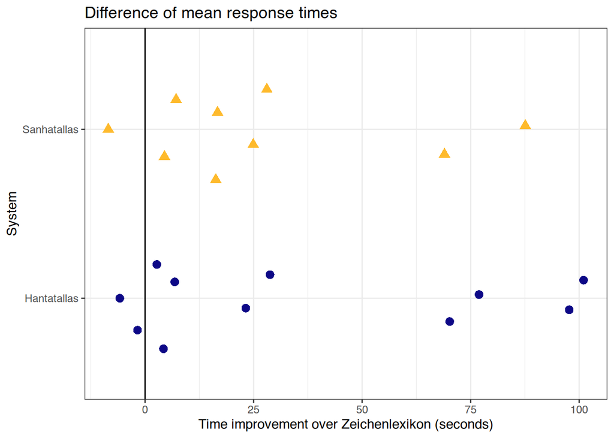

```r
set.seed(1)
ggplot() +
    geom_quasirandom(data=mean_diff_h, orientation='y', groupOnX=FALSE, size=3,
               mapping=aes(x=diff, y='Hantatallas', shape='Hantatallas', color='Hantatallas')) +
    geom_quasirandom(data=mean_diff_s, orientation='y', groupOnX=FALSE, size=3,
               mapping=aes(x=diff, y='Sanhatallas', shape='Sanhatallas', color='Sanhatallas')) +
    theme_bw() +
    geom_vline(xintercept=0) +
    scale_color_viridis(discrete=TRUE, option="plasma", begin=0, end=0.85) +
    labs(x="Time improvement over Zeichenlexikon (seconds)", y="System", title="Difference of mean response times", shape=NULL, color=NULL) +
    guides(shape="none", color="none")
```

```r
ggsave("r_mean_time_diff.pdf", width=6, height=4, units="in")
```

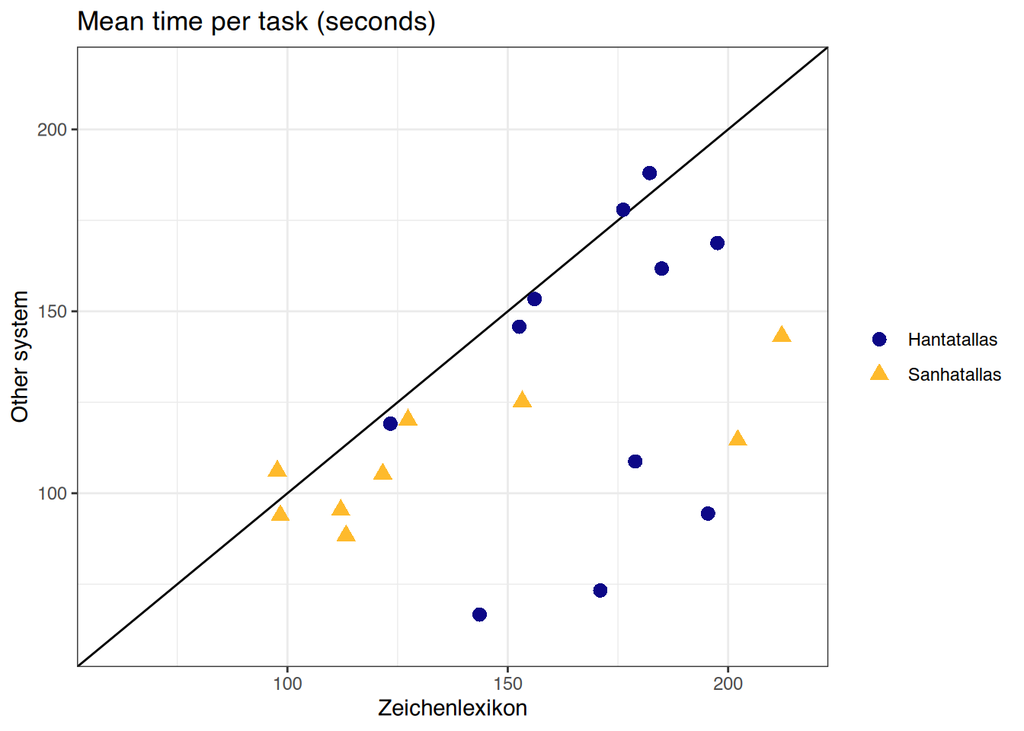

```r
set.seed(1)

ggplot() +
    geom_abline(slope=1, intercept=0) +
    geom_point(data=mean_diff_h, size=3,
               mapping=aes(x=mean_Z, y=mean_H, shape='Hantatallas', color='Hantatallas')) +
    geom_point(data=mean_diff_s, size=3,
               mapping=aes(x=mean_Z, y=mean_S, shape='Sanhatallas', color='Sanhatallas')) +
    xlim(60, 215) + ylim(60, 215) +
    theme_bw() +
    scale_color_viridis(discrete=TRUE, option="plasma", begin=0, end=0.85) +
    labs(x="Zeichenlexikon", y="Other system", title="Mean time per task (seconds)", shape=NULL, color=NULL)
```

```r
ggsave("r_mean_times.pdf", width=6, height=4, units="in")
```

```r
ratios_h <- mean_diff_h %>% mutate(time_ratio = mean_H / mean_Z, acc_ratio = accuracy_H / accuracy_Z)
show(ratios_h)
```

| subject | experience | mean_H | mean_Z | accuracy_H | accuracy_Z | diff | time_ratio | acc_ratio |
| --- | --- | --- | --- | --- | --- | --- | --- | --- |
| AX1 | 1 | 66.6628 | 143.6017 | 0.8750 | 0.8125 | 76.9389 | 0.4642 | 1.0769 |
| AY1 | 1 | 188.0144 | 182.1939 | 0.4375 | 0.3333 | -5.8204 | 1.0319 | 1.3125 |
| BX1 | 0 | 168.7784 | 197.5716 | 0.5333 | 0.4375 | 28.7932 | 0.8543 | 1.2190 |
| BY1 | 1 | 94.4240 | 195.4344 | 0.8750 | 0.6875 | 101.0104 | 0.4831 | 1.2727 |
| CX1 | 2+ | 153.3647 | 156.0853 | 0.8750 | 0.6250 | 2.7206 | 0.9826 | 1.4000 |
| CY1 | 1 | 177.9394 | 176.2026 | 0.9375 | 0.6875 | -1.7368 | 1.0099 | 1.3636 |
| PA1 | 1 | 119.1196 | 123.3654 | 0.8750 | 0.7500 | 4.2458 | 0.9656 | 1.1667 |
| PA2 | 1 | 73.2847 | 170.9957 | 0.5000 | 0.5625 | 97.7110 | 0.4286 | 0.8889 |
| PAE | 2+ | 108.7465 | 178.9274 | 0.6875 | 0.6000 | 70.1809 | 0.6078 | 1.1458 |
| PB1 | 1 | 145.7653 | 152.6079 | 0.7500 | 0.6875 | 6.8426 | 0.9552 | 1.0909 |
| PB2 | 2+ | 161.7433 | 184.9424 | 0.8000 | 0.7857 | 23.1991 | 0.8746 | 1.0182 |

```r
ratios_s <- mean_diff_s %>% mutate(time_ratio = mean_S / mean_Z, acc_ratio = accuracy_S / accuracy_Z)
show(ratios_s)
```

| subject | experience | mean_S | mean_Z | accuracy_S | accuracy_Z | diff | time_ratio | acc_ratio |
| --- | --- | --- | --- | --- | --- | --- | --- | --- |
| AX2 | 0 | 143.2074 | 212.1822 | 0.8125 | 0.7333 | 68.9748 | 0.6749 | 1.1080 |
| AX3 | 2+ | 93.9184 | 98.3962 | 0.4286 | 0.4286 | 4.4779 | 0.9545 | 1.0000 |
| AY2 | 1 | 114.5974 | 202.1880 | 0.6875 | 0.8571 | 87.5906 | 0.5668 | 0.8021 |
| BX2 | 1 | 125.2360 | 153.2918 | 0.9333 | 0.8125 | 28.0558 | 0.8170 | 1.1487 |
| BY2 | 1 | 95.3937 | 112.0988 | 0.8667 | 0.7500 | 16.7050 | 0.8510 | 1.1556 |
| BY3 | 2+ | 120.2071 | 127.3615 | 0.9375 | 0.9375 | 7.1544 | 0.9438 | 1.0000 |
| CX2 | 1 | 105.3427 | 121.6333 | 0.7500 | 0.8125 | 16.2906 | 0.8661 | 0.9231 |
| CX3 | 2+ | 106.1668 | 97.7015 | 1.0000 | 0.7500 | -8.4653 | 1.0866 | 1.3333 |
| CY2 | 0 | 88.3897 | 113.3156 | 0.8125 | 0.6875 | 24.9259 | 0.7800 | 1.1818 |

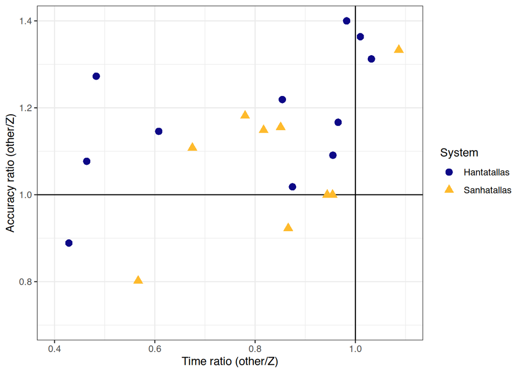

```r
ggplot() +
    geom_hline(yintercept=1) + geom_vline(xintercept=1) +
    geom_point(data=ratios_h, size=3,
               mapping=aes(x=time_ratio, y=acc_ratio, shape='Hantatallas', color='Hantatallas')) +
    geom_point(data=ratios_s, size=3,
               mapping=aes(x=time_ratio, y=acc_ratio, shape='Sanhatallas', color='Sanhatallas')) +
    theme_bw() +
#    scale_shape_manual(values=c(21, 24)) +
#    scale_x_log10() + scale_y_log10() + # On such a small scale it's literally imperceptible
    xlim(0.4, 1.1) + ylim(0.7, 1.4) +
    scale_color_viridis(discrete=TRUE, option="plasma", begin=0, end=0.85) +
    labs(x="Time ratio (other/Z)", y="Accuracy ratio (other/Z)", shape='System', color='System')
```

```r
ggsave("r_ratios.pdf", width=6, height=4, units="in")
```

Based on this, let’s define a new metric…

## Identification rate (formerly “efficiency”)

```r
eff_h <- mean_diff_h %>% mutate(efficiency_H = accuracy_H / mean_H * 60,
                                efficiency_Z = accuracy_Z / mean_Z * 60) %>%
                        mutate(eff_diff = efficiency_H - efficiency_Z)
show(eff_h)
```

| subject | experience | mean_H | mean_Z | accuracy_H | accuracy_Z | diff | efficiency_H | efficiency_Z | eff_diff |
| --- | --- | --- | --- | --- | --- | --- | --- | --- | --- |
| AX1 | 1 | 66.6628 | 143.6017 | 0.8750 | 0.8125 | 76.9389 | 0.7875 | 0.3395 | 0.4481 |
| AY1 | 1 | 188.0144 | 182.1939 | 0.4375 | 0.3333 | -5.8204 | 0.1396 | 0.1098 | 0.0298 |
| BX1 | 0 | 168.7784 | 197.5716 | 0.5333 | 0.4375 | 28.7932 | 0.1896 | 0.1329 | 0.0567 |
| BY1 | 1 | 94.4240 | 195.4344 | 0.8750 | 0.6875 | 101.0104 | 0.5560 | 0.2111 | 0.3449 |
| CX1 | 2+ | 153.3647 | 156.0853 | 0.8750 | 0.6250 | 2.7206 | 0.3423 | 0.2403 | 0.1021 |
| CY1 | 1 | 177.9394 | 176.2026 | 0.9375 | 0.6875 | -1.7368 | 0.3161 | 0.2341 | 0.0820 |
| PA1 | 1 | 119.1196 | 123.3654 | 0.8750 | 0.7500 | 4.2458 | 0.4407 | 0.3648 | 0.0760 |
| PA2 | 1 | 73.2847 | 170.9957 | 0.5000 | 0.5625 | 97.7110 | 0.4094 | 0.1974 | 0.2120 |
| PAE | 2+ | 108.7465 | 178.9274 | 0.6875 | 0.6000 | 70.1809 | 0.3793 | 0.2012 | 0.1781 |
| PB1 | 1 | 145.7653 | 152.6079 | 0.7500 | 0.6875 | 6.8426 | 0.3087 | 0.2703 | 0.0384 |
| PB2 | 2+ | 161.7433 | 184.9424 | 0.8000 | 0.7857 | 23.1991 | 0.2968 | 0.2549 | 0.0419 |

```r
eff_s <- mean_diff_s %>% mutate(efficiency_S = accuracy_S / mean_S * 60,
                                efficiency_Z = accuracy_Z / mean_Z * 60) %>%
                        mutate(eff_diff = efficiency_S - efficiency_Z)
show(eff_s)
```

| subject | experience | mean_S | mean_Z | accuracy_S | accuracy_Z | diff | efficiency_S | efficiency_Z | eff_diff |
| --- | --- | --- | --- | --- | --- | --- | --- | --- | --- |
| AX2 | 0 | 143.2074 | 212.1822 | 0.8125 | 0.7333 | 68.9748 | 0.3404 | 0.2074 | 0.1330 |
| AX3 | 2+ | 93.9184 | 98.3962 | 0.4286 | 0.4286 | 4.4779 | 0.2738 | 0.2613 | 0.0125 |
| AY2 | 1 | 114.5974 | 202.1880 | 0.6875 | 0.8571 | 87.5906 | 0.3600 | 0.2544 | 0.1056 |
| BX2 | 1 | 125.2360 | 153.2918 | 0.9333 | 0.8125 | 28.0558 | 0.4472 | 0.3180 | 0.1291 |
| BY2 | 1 | 95.3937 | 112.0988 | 0.8667 | 0.7500 | 16.7050 | 0.5451 | 0.4014 | 0.1437 |
| BY3 | 2+ | 120.2071 | 127.3615 | 0.9375 | 0.9375 | 7.1544 | 0.4679 | 0.4417 | 0.0263 |
| CX2 | 1 | 105.3427 | 121.6333 | 0.7500 | 0.8125 | 16.2906 | 0.4272 | 0.4008 | 0.0264 |
| CX3 | 2+ | 106.1668 | 97.7015 | 1.0000 | 0.7500 | -8.4653 | 0.5651 | 0.4606 | 0.1046 |
| CY2 | 0 | 88.3897 | 113.3156 | 0.8125 | 0.6875 | 24.9259 | 0.5515 | 0.3640 | 0.1875 |

“Identification rate” is defined as mean accuracy over mean time (scaled by 1/60 to correct answers per minute), to compensate for the outliers in the above plot. In other words, it’s meant to measure how effectively people used the time they spent. Let’s see how it stacks up!

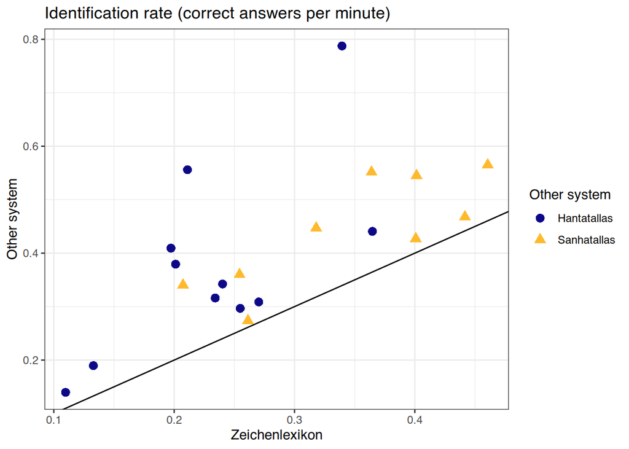

```r
ggplot() +
    geom_abline(slope=1, intercept=0) +
    geom_point(data=eff_h, size=3,
               mapping=aes(x=efficiency_Z, y=efficiency_H, shape='Hantatallas', color='Hantatallas')) +
    geom_point(data=eff_s, size=3,
               mapping=aes(x=efficiency_Z, y=efficiency_S, shape='Sanhatallas', color='Sanhatallas')) +
    theme_bw() +
    scale_color_viridis(discrete=TRUE, option="plasma", begin=0, end=0.85) +
#    xlim(0.002, 0.016) + ylim(0.002, 0.016)
    labs(x="Zeichenlexikon", y="Other system", title="Identification rate (correct answers per minute)", shape='Other system', color='Other system')
```

```r
ggsave("r_efficiency.pdf", width=6, height=4, units="in")
```

This rate seems to differ more between systems than accuracy does. Let’s try a t-test on it.

```r
shapiro.test(eff_s$eff_diff)
```

```
##
##  Shapiro-Wilk normality test
##
## data:  eff_s$eff_diff
## W = 0.90398, p-value = 0.276
```

```r
t.test(x=eff_s$efficiency_S, y=eff_s$efficiency_Z, paired=TRUE)
```

```
##
##  Paired t-test
##
## data:  eff_s$efficiency_S and eff_s$efficiency_Z
## t = 4.7311, df = 8, p-value = 0.001481
## alternative hypothesis: true mean difference is not equal to 0
## 95 percent confidence interval:
##  0.04947282 0.14356100
## sample estimates:
## mean difference
##      0.09651691
```

```r
wilcox.test(x=eff_s$efficiency_S, y=eff_s$efficiency_Z, paired=TRUE)
```

```
##
##  Wilcoxon signed rank exact test
##
## data:  eff_s$efficiency_S and eff_s$efficiency_Z
## V = 45, p-value = 0.003906
## alternative hypothesis: true location shift is not equal to 0
```

# Task difficulty

It’s also worth asking if some tasks are more difficult than others.

```r
tasks <- filtered %>% group_by(task) %>% summarize(accuracy=mean(accurate), time=mean(time))
tasks %>% head() %>% show()
```

| task | accuracy | time |
| --- | --- | --- |
| 0_bal | 0.8889 | 164.6852 |
| 0_ca3 | 0.7857 | 137.4715 |
| 0_cudun3 | 0.3333 | 288.9260 |
| 0_dam | 0.5333 | 122.0925 |
| 0_elam | 0.7000 | 141.4779 |
| 0_ezen4 | 0.6667 | 208.4122 |

```r
# Look only at E-lists (main experiment), but with the mean across all tests, including pilot trials
tmp <- filtered %>% filter(list=="E1" | list=="E2" | list=="E3")
# The join looks up the entries in `tasks` that match the `task` in `tmp`
tasklists <- inner_join(tasks, tmp, by=c("task")) %>% group_by(task, damage, list, accuracy, time.x) %>% summarize(.groups="drop") %>% rename(time=time.x) %>% arrange(list, damage, task) %>% mutate(task.sorted=factor(task, levels=task)) # Change sort order of the factor
tasklists %>% head() %>% show()
```

| task | damage | list | accuracy | time | task.sorted |
| --- | --- | --- | --- | --- | --- |
| 0_cudun3 | 0 | E1 | 0.3333 | 288.9260 | 0_cudun3 |
| 0_gur | 0 | E1 | 1.0000 | 71.9183 | 0_gur |
| 0_kac4 | 0 | E1 | 0.5333 | 146.1815 | 0_kac4 |
| 0_kiri6 | 0 | E1 | 0.9286 | 99.2440 | 0_kiri6 |
| 0_nita2 | 0 | E1 | 0.9333 | 85.7391 | 0_nita2 |
| 0_sig2+munus | 0 | E1 | 0.5000 | 204.7987 | 0_sig2+munus |

Now, are some of the lists more difficult than others?

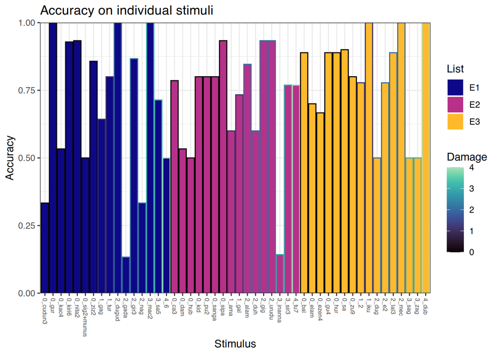

```r
ggplot(tasklists, aes(x=task.sorted, y=accuracy, fill=list, colour=damage)) +
    geom_bar(stat="identity") +
    theme_bw() +
    scale_color_viridis(option="mako", begin=0, end=0.9) +
    scale_fill_viridis(discrete=TRUE, option="plasma", begin=0, end=0.85) +
    theme(axis.text.x = element_text(angle = -90, vjust = 0.5, hjust=0, size=6)) +
    labs(title="Accuracy on individual stimuli", x="Stimulus", y="Accuracy", fill="List", color="Damage") +
    scale_y_continuous(expand = expansion(mult = c(0, 0))) # Remove bottom and top margins
```

```r
ggsave("r_stimuli1.pdf", width=6, height=4, units="in")
```

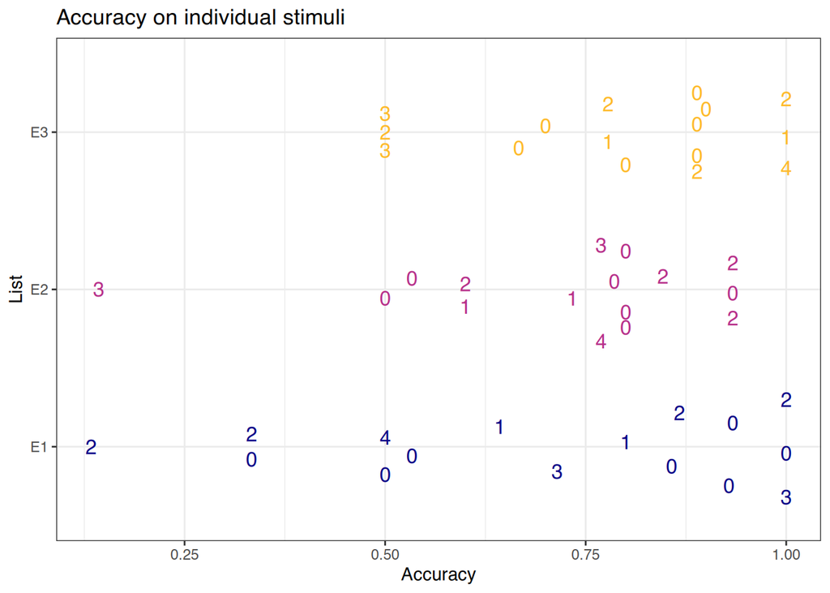

```r
ggplot(tasklists, aes(x=accuracy, y=list, color=list, shape=as.factor(damage))) +
    geom_quasirandom(size=3, orientation='y', groupOnX=FALSE, stroke=2) +
    theme_bw() +
#    scale_shape_manual(values=c(21,22,23,24,25)) +
    scale_shape_manual(values=c(48, 49, 50, 51, 52)) +
    scale_color_viridis(discrete=TRUE, option="plasma", begin=0, end=0.85) +
    scale_fill_viridis(discrete=TRUE, option="plasma", begin=0, end=0.85) +
    labs(title="Accuracy on individual stimuli", x="Accuracy", y="List", shape='Damage', color='List') +
    guides(color="none", fill="none", shape="none") #+
```

```r
#    theme(legend.text=element_text(size=0)) # Hack to get rid of legend text
```

```r
ggsave("r_stimuli2.pdf", width=6, height=4, units="in")
```

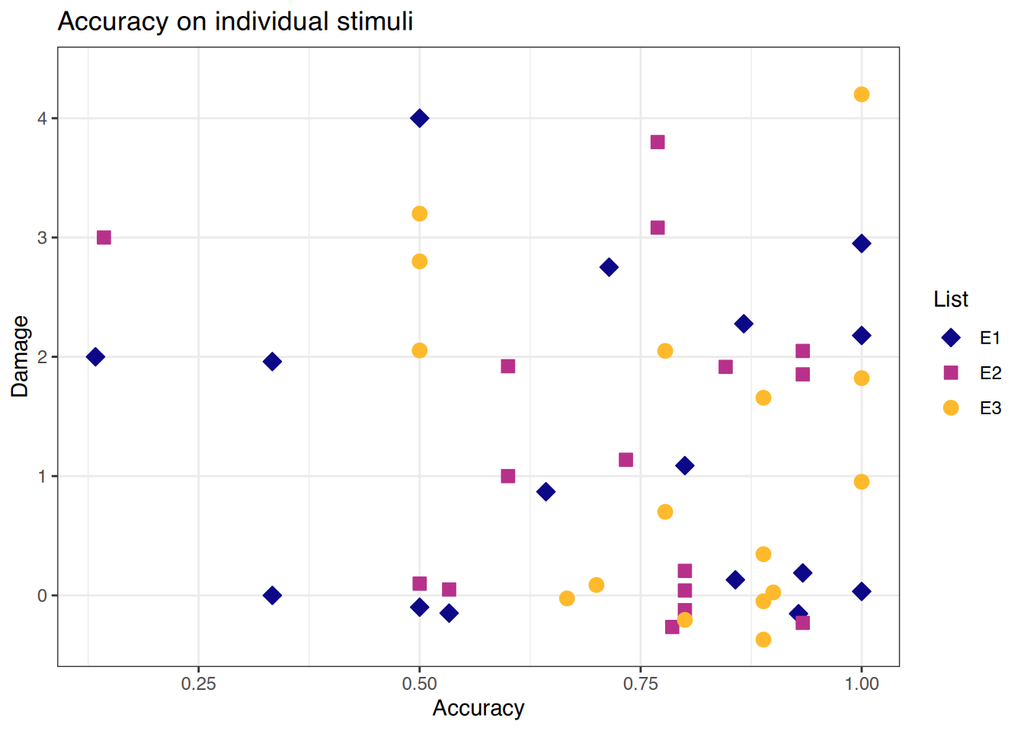

```r
ggplot(tasklists, aes(x=accuracy, y=as.factor(damage), color=list, fill=list, shape=list)) +
    geom_quasirandom(size=3, orientation='y', groupOnX=FALSE) +
    theme_bw() +
    scale_shape_manual(values=c(23,22,21)) +
#    scale_shape_manual(values=c(48, 49, 50, 51, 52)) +
    scale_color_viridis(discrete=TRUE, option="plasma", begin=0, end=0.85) +
    scale_fill_viridis(discrete=TRUE, option="plasma", begin=0, end=0.85) +
    labs(title='Accuracy on individual stimuli', x="Accuracy", y="Damage", color='List', fill='List', shape='List')
```

```r
ggsave("r_stimuli3.pdf", width=6, height=4, units="in")
```

What about the time taken?

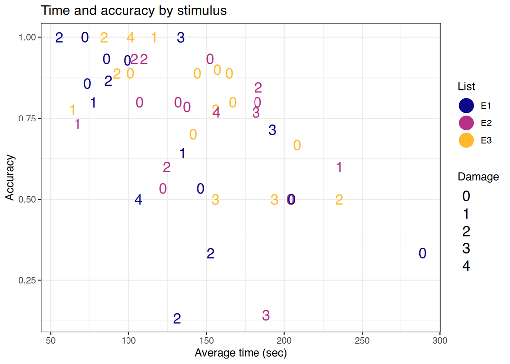

```r
ggplot(tasklists, aes(x=time, y=accuracy, color=list, shape=as.factor(damage))) +
    geom_quasirandom(groupOnX=TRUE, size=3, stroke=3) +
    theme_bw() +
    scale_shape_manual(values=c(48, 49, 50, 51, 52)) +
    scale_color_viridis(discrete=TRUE, option="plasma", begin=0, end=0.85) +
    labs(title='Time and accuracy by stimulus', x='Average time (sec)', y='Accuracy', color='List', shape='Damage') +
    guides(shape=guide_legend(theme=theme(legend.text=element_text(size=0)))) # Hack to get rid of legend text
```

```r
ggsave("r_stimtimeacc.pdf", width=6, height=4, units="in")
```

It looks like a negative correlation here. How strong is it?

```r
cor.test(tasklists$time, tasklists$accuracy, method="spearman")
```

```
##
##  Spearman's rank correlation rho
##
## data:  tasklists$time and tasklists$accuracy
## S = 28633, p-value = 4.39e-05
## alternative hypothesis: true rho is not equal to 0
## sample estimates:
##        rho
## -0.5541094
```

Let’s plot that correlation and see.

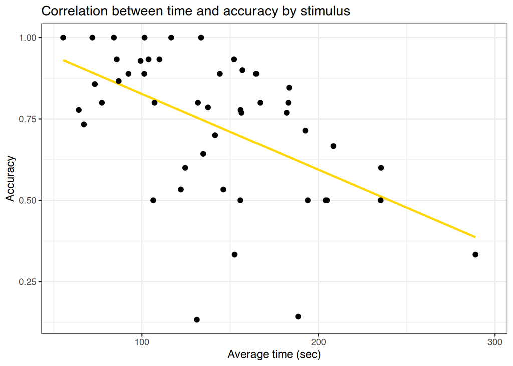

```r
ggplot(tasklists, aes(x=time, y=accuracy)) +
    geom_smooth(formula=y~x, method="lm", color="gold", se=FALSE) +
    geom_quasirandom(groupOnX=TRUE, size=2) +
    theme_bw() +
    xlim(55, 295) + # Don't cut off the rightmost label
#    geom_smooth(formula=y~x, method="loess", color="red", se=FALSE) +
    labs(title='Correlation between time and accuracy by stimulus', x='Average time (sec)', y='Accuracy')
```

```r
ggsave("r_stimcorr.pdf", width=6, height=4, units="in")
```

Let’s generate another bar plot for time, so we can look at that extreme outlier.

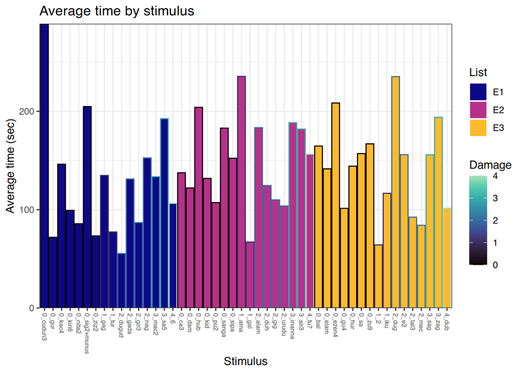

```r
ggplot(tasklists, aes(x=task.sorted, y=time, fill=list, colour=damage)) +
    geom_bar(stat="identity") +
    theme_bw() +
    scale_color_viridis(option="mako", begin=0, end=0.9) +
    scale_fill_viridis(discrete=TRUE, option="plasma", begin=0, end=0.85) +
    theme(axis.text.x = element_text(angle = -90, vjust = 0.5, hjust=0, size=6)) +
    labs(title="Average time by stimulus", x="Stimulus", y="Average time (sec)", fill="List", color="Damage") +
    scale_y_continuous(expand = expansion(mult = c(0, 0))) # Remove bottom and top margins
```

```r
ggsave("r_stimtime.pdf", width=6, height=4, units="in")
```

It looks like we have four outliers to remove.

```r
str(tasklists)
```

```
## tibble [48 × 6] (S3: tbl_df/tbl/data.frame)
##  $ task       : Factor w/ 48 levels "0_bal","0_ca3",..: 3 8 11 13 14 18 20 24 27 30 ...
##  $ damage     : int [1:48] 0 0 0 0 0 0 0 1 1 2 ...
##  $ list       : Factor w/ 5 levels "E1","E2","E3",..: 1 1 1 1 1 1 1 1 1 1 ...
##  $ accuracy   : num [1:48] 0.333 1 0.533 0.929 0.933 ...
##  $ time       : num [1:48] 288.9 71.9 146.2 99.2 85.7 ...
##  $ task.sorted: Factor w/ 48 levels "0_cudun3","0_gur",..: 1 2 3 4 5 6 7 8 9 10 ...
```

```r
tasklists_clean <- tasklists %>% filter(task.sorted %notin% c("0_cudun3", "2_gada", "2_nag", "3_inanna"))
str(tasklists_clean)
```

```
## tibble [44 × 6] (S3: tbl_df/tbl/data.frame)
##  $ task       : Factor w/ 48 levels "0_bal","0_ca3",..: 8 11 13 14 18 20 24 27 30 35 ...
##  $ damage     : int [1:44] 0 0 0 0 0 0 1 1 2 2 ...
##  $ list       : Factor w/ 5 levels "E1","E2","E3",..: 1 1 1 1 1 1 1 1 1 1 ...
##  $ accuracy   : num [1:44] 1 0.533 0.929 0.933 0.5 ...
##  $ time       : num [1:44] 71.9 146.2 99.2 85.7 204.8 ...
##  $ task.sorted: Factor w/ 48 levels "0_cudun3","0_gur",..: 2 3 4 5 6 7 8 9 10 12 ...
```

Let’s re-run our correlation now.

```r
cor.test(tasklists_clean$time, tasklists_clean$accuracy, method="spearman")
```

```
##
##  Spearman's rank correlation rho
##
## data:  tasklists_clean$time and tasklists_clean$accuracy
## S = 21793, p-value = 0.0001783
## alternative hypothesis: true rho is not equal to 0
## sample estimates:
##        rho
## -0.5357717
```

And plot it, too!

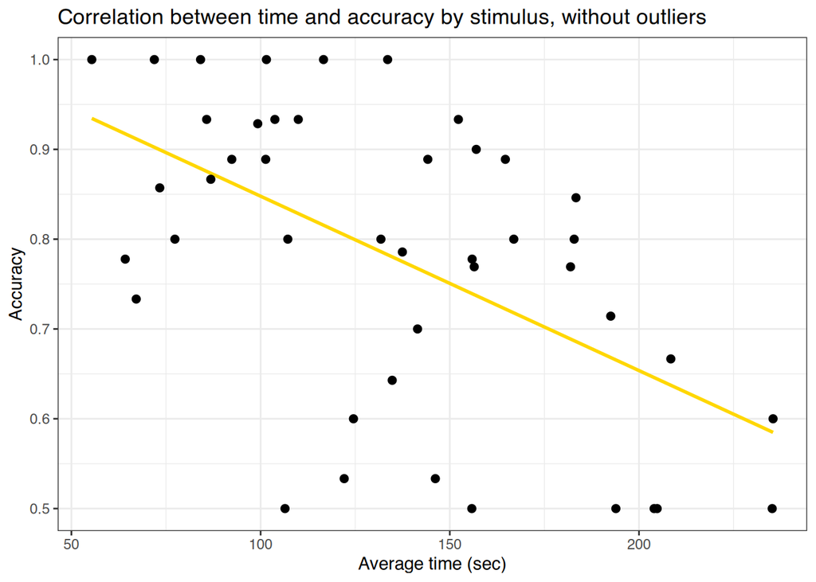

```r
ggplot(tasklists_clean, aes(x=time, y=accuracy)) +
    geom_smooth(formula=y~x, method="lm", color="gold", se=FALSE) +
    geom_quasirandom(groupOnX=TRUE, size=2) +
    theme_bw() +
#    geom_smooth(formula=y~x, method="loess", color="red", se=FALSE) +
    labs(title='Correlation between time and accuracy by stimulus, without outliers', x='Average time (sec)', y='Accuracy')
```

```r
ggsave("r_stimcorr2.pdf", width=6, height=4, units="in")
```

It doesn’t look like there are any other correlations. Let’s make sure of that.

```r
library(psych)
```

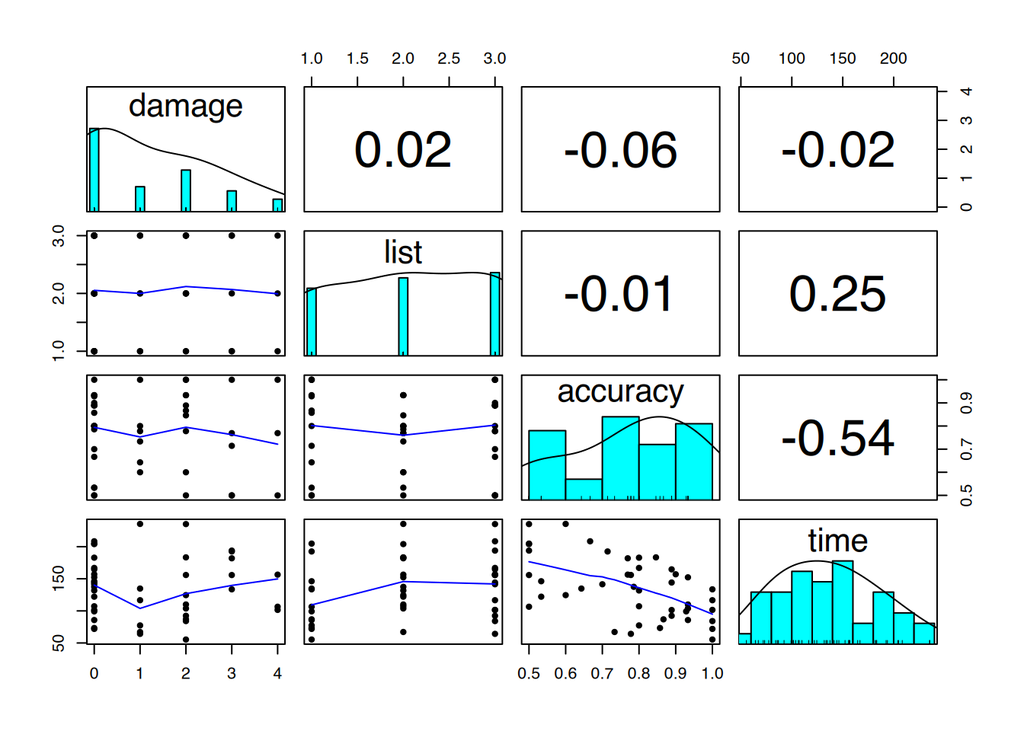

```r
psych::pairs.panels(tasklists_clean[c("damage","list","accuracy","time")], method="spearman", density=TRUE, ellipses=FALSE)
```

# Logistical Stuff

Finally, let’s generate some tables needed for the thesis, showing the stuff we already know but in a more compact way.

Data about the subjects:

```r
subjdata <- filtered %>% mutate(semesters=ceiling(semesters)) %>%
    group_by(subject, system, semesters, experience, enrolled, list) %>%
    summarize(acc_mean = mean(accurate), acc_std = sd(accurate), time_mean = mean(time), time_std = sd(time)) %>%
    arrange(system) %>%
    pivot_wider(names_from=system, values_from=c(acc_mean, acc_std, time_mean, time_std, list))
```

[output not shown]

```r
subjdata %>% show()
```

| subject | semesters | experience | enrolled | acc_mean_H | acc_mean_S | acc_mean_Z | acc_std_H | acc_std_S | acc_std_Z | time_mean_H | time_mean_S | time_mean_Z | time_std_H | time_std_S | time_std_Z | list_H | list_S | list_Z |
| --- | --- | --- | --- | --- | --- | --- | --- | --- | --- | --- | --- | --- | --- | --- | --- | --- | --- | --- |
| AX1 | 1 | 1 | yes | 0.8750 |  | 0.8125 | 0.3416 |  | 0.4031 | 66.6628 |  | 143.6017 | 36.8347 |  | 68.6019 | E1 |  | E2 |
| AY1 | 1 | 1 | yes | 0.4375 |  | 0.3333 | 0.5123 |  | 0.4880 | 188.0144 |  | 182.1939 | 125.9748 |  | 115.5094 | E1 |  | E2 |
| BX1 | 0 | 0 | no | 0.5333 |  | 0.4375 | 0.5164 |  | 0.5123 | 168.7784 |  | 197.5716 | 122.4406 |  | 116.5660 | E2 |  | E3 |
| BY1 | 1 | 1 | yes | 0.8750 |  | 0.6875 | 0.3416 |  | 0.4787 | 94.4240 |  | 195.4344 | 63.9230 |  | 149.0974 | E2 |  | E3 |
| CX1 | 2 | 2+ | no | 0.8750 |  | 0.6250 | 0.3416 |  | 0.5000 | 153.3647 |  | 156.0853 | 101.0502 |  | 94.5879 | E3 |  | E1 |
| CY1 | 1 | 1 | yes | 0.9375 |  | 0.6875 | 0.2500 |  | 0.4787 | 177.9394 |  | 176.2026 | 103.4812 |  | 109.3937 | E3 |  | E1 |
| PA1 | 1 | 1 | no | 0.8750 |  | 0.7500 | 0.3416 |  | 0.4472 | 119.1196 |  | 123.3654 | 88.1393 |  | 68.5221 | P1 |  | P2 |
| PA2 | 1 | 1 | no | 0.5000 |  | 0.5625 | 0.5164 |  | 0.5123 | 73.2847 |  | 170.9957 | 37.6286 |  | 89.0921 | P1 |  | P2 |
| PAE | 4 | 2+ | no | 0.6875 |  | 0.6000 | 0.4787 |  | 0.5071 | 108.7465 |  | 178.9274 | 62.6373 |  | 84.2966 | P1 |  | P2 |
| PB1 | 1 | 1 | no | 0.7500 |  | 0.6875 | 0.4472 |  | 0.4787 | 145.7653 |  | 152.6079 | 116.1121 |  | 86.1315 | P2 |  | P1 |
| PB2 | 2 | 2+ | no | 0.8000 |  | 0.7857 | 0.4140 |  | 0.4258 | 161.7433 |  | 184.9424 | 115.7022 |  | 84.9916 | P2 |  | P1 |
| AX2 | 0 | 0 | no |  | 0.8125 | 0.7333 |  | 0.4031 | 0.4577 |  | 143.2074 | 212.1822 |  | 143.5433 | 141.1002 |  | E1 | E2 |
| AX3 | 3 | 2+ | no |  | 0.4286 | 0.4286 |  | 0.5136 | 0.5136 |  | 93.9184 | 98.3962 |  | 60.1111 | 59.1222 |  | E1 | E2 |
| AY2 | 1 | 1 | yes |  | 0.6875 | 0.8571 |  | 0.4787 | 0.3631 |  | 114.5974 | 202.1880 |  | 146.3308 | 115.9640 |  | E1 | E2 |
| BX2 | 1 | 1 | yes |  | 0.9333 | 0.8125 |  | 0.2582 | 0.4031 |  | 125.2360 | 153.2918 |  | 62.8590 | 89.0168 |  | E2 | E3 |
| BY2 | 1 | 1 | yes |  | 0.8667 | 0.7500 |  | 0.3519 | 0.4472 |  | 95.3937 | 112.0988 |  | 81.0769 | 56.3826 |  | E2 | E3 |
| BY3 | 8 | 2+ | yes |  | 0.9375 | 0.9375 |  | 0.2500 | 0.2500 |  | 120.2071 | 127.3615 |  | 76.0358 | 137.3268 |  | E2 | E3 |
| CX2 | 1 | 1 | yes |  | 0.7500 | 0.8125 |  | 0.4472 | 0.4031 |  | 105.3427 | 121.6333 |  | 68.1197 | 70.8625 |  | E3 | E1 |
| CX3 | 17 | 2+ | yes |  | 1.0000 | 0.7500 |  | 0.0000 | 0.4523 |  | 106.1668 | 97.7015 |  | 85.5742 | 130.3092 |  | E3 | E1 |
| CY2 | 0 | 0 | no |  | 0.8125 | 0.6875 |  | 0.4031 | 0.4787 |  | 88.3897 | 113.3156 |  | 84.3172 | 46.8793 |  | E3 | E1 |

```r
tmp_eff = full_join(eff_h, eff_s, by=c("subject"))
tmp_eff$efficiency_Z = coalesce(tmp_eff$efficiency_Z.x, tmp_eff$efficiency_Z.y)
eff <- tmp_eff %>% select(subject, efficiency_H, efficiency_S, efficiency_Z)
eff %>% show()
```

| subject | efficiency_H | efficiency_S | efficiency_Z |
| --- | --- | --- | --- |
| AX1 | 0.7875 |  | 0.3395 |
| AY1 | 0.1396 |  | 0.1098 |
| BX1 | 0.1896 |  | 0.1329 |
| BY1 | 0.5560 |  | 0.2111 |
| CX1 | 0.3423 |  | 0.2403 |
| CY1 | 0.3161 |  | 0.2341 |
| PA1 | 0.4407 |  | 0.3648 |
| PA2 | 0.4094 |  | 0.1974 |
| PAE | 0.3793 |  | 0.2012 |
| PB1 | 0.3087 |  | 0.2703 |
| PB2 | 0.2968 |  | 0.2549 |
| AX2 |  | 0.3404 | 0.2074 |
| AX3 |  | 0.2738 | 0.2613 |
| AY2 |  | 0.3600 | 0.2544 |
| BX2 |  | 0.4472 | 0.3180 |
| BY2 |  | 0.5451 | 0.4014 |
| BY3 |  | 0.4679 | 0.4417 |
| CX2 |  | 0.4272 | 0.4008 |
| CX3 |  | 0.5651 | 0.4606 |
| CY2 |  | 0.5515 | 0.3640 |

```r
subjdata_full = full_join(subjdata, eff, by=c("subject")) %>% ungroup()
subjdata_full %>% select(subject, semesters, experience, enrolled, list_H, list_S, list_Z) %>% show()
```

| subject | semesters | experience | enrolled | list_H | list_S | list_Z |
| --- | --- | --- | --- | --- | --- | --- |
| AX1 | 1 | 1 | yes | E1 |  | E2 |
| AY1 | 1 | 1 | yes | E1 |  | E2 |
| BX1 | 0 | 0 | no | E2 |  | E3 |
| BY1 | 1 | 1 | yes | E2 |  | E3 |
| CX1 | 2 | 2+ | no | E3 |  | E1 |
| CY1 | 1 | 1 | yes | E3 |  | E1 |
| PA1 | 1 | 1 | no | P1 |  | P2 |
| PA2 | 1 | 1 | no | P1 |  | P2 |
| PAE | 4 | 2+ | no | P1 |  | P2 |
| PB1 | 1 | 1 | no | P2 |  | P1 |
| PB2 | 2 | 2+ | no | P2 |  | P1 |
| AX2 | 0 | 0 | no |  | E1 | E2 |
| AX3 | 3 | 2+ | no |  | E1 | E2 |
| AY2 | 1 | 1 | yes |  | E1 | E2 |
| BX2 | 1 | 1 | yes |  | E2 | E3 |
| BY2 | 1 | 1 | yes |  | E2 | E3 |
| BY3 | 8 | 2+ | yes |  | E2 | E3 |
| CX2 | 1 | 1 | yes |  | E3 | E1 |
| CX3 | 17 | 2+ | yes |  | E3 | E1 |
| CY2 | 0 | 0 | no |  | E3 | E1 |

```r
subjdata_full %>% select(subject, acc_mean_H, acc_mean_S, acc_mean_Z, acc_std_H, acc_std_S, acc_std_Z) %>% show()
```

| subject | acc_mean_H | acc_mean_S | acc_mean_Z | acc_std_H | acc_std_S | acc_std_Z |
| --- | --- | --- | --- | --- | --- | --- |
| AX1 | 0.8750 |  | 0.8125 | 0.3416 |  | 0.4031 |
| AY1 | 0.4375 |  | 0.3333 | 0.5123 |  | 0.4880 |
| BX1 | 0.5333 |  | 0.4375 | 0.5164 |  | 0.5123 |
| BY1 | 0.8750 |  | 0.6875 | 0.3416 |  | 0.4787 |
| CX1 | 0.8750 |  | 0.6250 | 0.3416 |  | 0.5000 |
| CY1 | 0.9375 |  | 0.6875 | 0.2500 |  | 0.4787 |
| PA1 | 0.8750 |  | 0.7500 | 0.3416 |  | 0.4472 |
| PA2 | 0.5000 |  | 0.5625 | 0.5164 |  | 0.5123 |
| PAE | 0.6875 |  | 0.6000 | 0.4787 |  | 0.5071 |
| PB1 | 0.7500 |  | 0.6875 | 0.4472 |  | 0.4787 |
| PB2 | 0.8000 |  | 0.7857 | 0.4140 |  | 0.4258 |
| AX2 |  | 0.8125 | 0.7333 |  | 0.4031 | 0.4577 |
| AX3 |  | 0.4286 | 0.4286 |  | 0.5136 | 0.5136 |
| AY2 |  | 0.6875 | 0.8571 |  | 0.4787 | 0.3631 |
| BX2 |  | 0.9333 | 0.8125 |  | 0.2582 | 0.4031 |
| BY2 |  | 0.8667 | 0.7500 |  | 0.3519 | 0.4472 |
| BY3 |  | 0.9375 | 0.9375 |  | 0.2500 | 0.2500 |
| CX2 |  | 0.7500 | 0.8125 |  | 0.4472 | 0.4031 |
| CX3 |  | 1.0000 | 0.7500 |  | 0.0000 | 0.4523 |
| CY2 |  | 0.8125 | 0.6875 |  | 0.4031 | 0.4787 |

```r
subjdata_full %>% select(subject, time_mean_H, time_mean_S, time_mean_Z, time_std_H, time_std_S, time_std_Z) %>% show()
```

| subject | time_mean_H | time_mean_S | time_mean_Z | time_std_H | time_std_S | time_std_Z |
| --- | --- | --- | --- | --- | --- | --- |
| AX1 | 66.6628 |  | 143.6017 | 36.8347 |  | 68.6019 |
| AY1 | 188.0144 |  | 182.1939 | 125.9748 |  | 115.5094 |
| BX1 | 168.7784 |  | 197.5716 | 122.4406 |  | 116.5660 |
| BY1 | 94.4240 |  | 195.4344 | 63.9230 |  | 149.0974 |
| CX1 | 153.3647 |  | 156.0853 | 101.0502 |  | 94.5879 |
| CY1 | 177.9394 |  | 176.2026 | 103.4812 |  | 109.3937 |
| PA1 | 119.1196 |  | 123.3654 | 88.1393 |  | 68.5221 |
| PA2 | 73.2847 |  | 170.9957 | 37.6286 |  | 89.0921 |
| PAE | 108.7465 |  | 178.9274 | 62.6373 |  | 84.2966 |
| PB1 | 145.7653 |  | 152.6079 | 116.1121 |  | 86.1315 |
| PB2 | 161.7433 |  | 184.9424 | 115.7022 |  | 84.9916 |
| AX2 |  | 143.2074 | 212.1822 |  | 143.5433 | 141.1002 |
| AX3 |  | 93.9184 | 98.3962 |  | 60.1111 | 59.1222 |
| AY2 |  | 114.5974 | 202.1880 |  | 146.3308 | 115.9640 |
| BX2 |  | 125.2360 | 153.2918 |  | 62.8590 | 89.0168 |
| BY2 |  | 95.3937 | 112.0988 |  | 81.0769 | 56.3826 |
| BY3 |  | 120.2071 | 127.3615 |  | 76.0358 | 137.3268 |
| CX2 |  | 105.3427 | 121.6333 |  | 68.1197 | 70.8625 |
| CX3 |  | 106.1668 | 97.7015 |  | 85.5742 | 130.3092 |
| CY2 |  | 88.3897 | 113.3156 |  | 84.3172 | 46.8793 |

```r
subjdata_full %>% select(subject, efficiency_H, efficiency_S, efficiency_Z) %>% show() # Could add more to this one
```

| subject | efficiency_H | efficiency_S | efficiency_Z |
| --- | --- | --- | --- |
| AX1 | 0.7875 |  | 0.3395 |
| AY1 | 0.1396 |  | 0.1098 |
| BX1 | 0.1896 |  | 0.1329 |
| BY1 | 0.5560 |  | 0.2111 |
| CX1 | 0.3423 |  | 0.2403 |
| CY1 | 0.3161 |  | 0.2341 |
| PA1 | 0.4407 |  | 0.3648 |
| PA2 | 0.4094 |  | 0.1974 |
| PAE | 0.3793 |  | 0.2012 |
| PB1 | 0.3087 |  | 0.2703 |
| PB2 | 0.2968 |  | 0.2549 |
| AX2 |  | 0.3404 | 0.2074 |
| AX3 |  | 0.2738 | 0.2613 |
| AY2 |  | 0.3600 | 0.2544 |
| BX2 |  | 0.4472 | 0.3180 |
| BY2 |  | 0.5451 | 0.4014 |
| BY3 |  | 0.4679 | 0.4417 |
| CX2 |  | 0.4272 | 0.4008 |
| CX3 |  | 0.5651 | 0.4606 |
| CY2 |  | 0.5515 | 0.3640 |